# Inspect external contamination of the inoculum

Michael McLaren

2020-08-01

Goal: Examine the presence of strains that should not, by design, be in the inoculum samples. This analyses was conducted in 2020-02, and was updated on 2020-08-01 to use the new results files and create an html report.

## Setup

```r
library(speedyseq)
library(tidyverse)
library(here)
library(cowplot)
library(ggridges)
library(ggbeeswarm)
library(ggforce)
theme_set(theme_minimal_grid(12))
```

```r
my_psmelt <- function(physeq) {
  speedyseq::psmelt(physeq) %>%
    as_tibble %>%
    rename(taxon = OTU, sample = Sample, abundance = Abundance)
}
as_tibble.phyloseq <- function(x) {
  x %>% my_psmelt
}
as_tibble.sample_data <- function(x) {
  x %>% as("data.frame") %>% as_tibble(rownames = "sample")
}
as_tibble.taxonomyTable <- function(x) {
  x %>% as("matrix") %>% as_tibble(rownames = "taxon")
}
as_tibble.XStringSet <- function(x) {
  x %>% as.character %>% enframe("taxon", "sequence")
}
```

Import into phyloseq.

```r
ps <- readRDS(here("results/a1/a1-phyloseq-silva-v138.Rds")) %>%
  print
```

```
## phyloseq-class experiment-level object
## otu_table()   OTU Table:         [ 367 taxa and 96 samples ]
## sample_data() Sample Data:       [ 96 samples by 22 sample variables ]
## tax_table()   Taxonomy Table:    [ 367 taxa by 7 taxonomic ranks ]
## refseq()      DNAStringSet:      [ 367 reference sequences ]
```

```r
sample_data(ps) <- sample_data(ps) %>%
  transform(extraction_batch = as.factor(extraction_batch))
```

```r
pstb <- ps %>% as_tibble
tax <- tax_table(ps) %>% as_tibble
ref <- refseq(ps) %>% as_tibble
sam <- sample_data(ps) %>% as_tibble
```

```r
custom_species <- dada2::assignSpecies(
  ref$sequence,
  here("strain-info", "inoculum-tmob-zymo-16s.fasta"),
  verbose = TRUE
  ) %>%
  as_tibble(rownames = "sequence") %>%
  rename_all(str_to_lower) %>%
  left_join(ref, by = "sequence")
```

```
## 22 out of 367 were assigned to the species level.
```

```r
custom_species %>% filter(!is.na(genus)) %>% print(n=Inf)
```

```
## # A tibble: 22 x 4
##    sequence                                genus        species     taxon
##    <chr>                                   <chr>        <chr>       <chr>
##  1 TACGGAGGATCCGAGCGTTATCCGGATTTATTGGGTTT… Bacteroides  ovatus      A1_AS…
##  2 TACGGAGGGTGCAAGCGTTAATCGGAATTACTGGGCGT… Escherichia… coli        A1_AS…
##  3 TACAGAGGTCTCAAGCGTTGTTCGGAATCACTGGGCGT… Akkermansia  muciniphila A1_AS…
##  4 TACGGAGGATCCGAGCGTTATCCGGATTTATTGGGTTT… Bacteroides  uniformis   A1_AS…
##  5 TACGGAGGATCCGAGCGTTATCCGGATTTATTGGGTTT… Bacteroides  thetaiotao… A1_AS…
##  6 TACGTAGGTGGCAAGCGTTATCCGGAATTATTGGGCGT… Staphylococ… aureus      A1_AS…
##  7 TACGTAGGGGGCAAGCGTTATCCGGATTTACTGGGTGT… Clostridium  symbiosum   A1_AS…
##  8 TACGTATGGTGCAAGCGTTATCCGGATTTACTGGGTGT… Roseburia    intestinal… A1_AS…
##  9 TACGGAGGATCCGAGCGTTATCCGGATTTATTGGGTTT… Bacteroides  caccae      A1_AS…
## 10 TACGGAGGGTGCAAGCGTTAATCGGAATCACTGGGCGT… Thioflavico… mobilis     A1_AS…
## 11 AACGTAGGTCACAAGCGTTGTCCGGAATTACTGGGTGT… Faecalibact… prausnitzii A1_AS…
## 12 TACGTAGGGGGCGAGCGTTATCCGGATTCATTGGGCGT… Collinsella  aerofaciens A1_AS…
## 13 TACGTAGGGGGCAAGCGTTATCCGGATTTACTGGGTGT… Marvinbryan… formatexig… A1_AS…
## 14 TACGTATGGTGCAAGCGTTATCCGGATTTACTGGGTGT… Eubacterium  rectale     A1_AS…
## 15 TACGGAGGATGCGAGCGTTATCCGGATTTATTGGGTTT… Barnesiella  intestinih… A1_AS…
## 16 TACGGAGGATGCGAGCGTTATCCGGATTTATTGGGTTT… Barnesiella  intestinih… A1_AS…
## 17 TACGTAGGTGGCAAGCGTTATCCGGATTTATTGGGCGT… Lactobacill… fermentum   A1_AS…
## 18 TACGTAGGTGGCAAGCGTTGTCCGGAATTATTGGGCGT… Bacillus     subtilis    A1_AS…
## 19 TACGGAGGGTGCAAGCGTTAATCGGAATTACTGGGCGT… Salmonella   enterica    A1_AS…
## 20 TACGTAGGTGGCAAGCGTTGTCCGGATTTATTGGGCGT… Listeria     monocytoge… A1_AS…
## 21 TACGTAGGTGGCAAGCGTTGTCCGGATTTATTGGGCGT… Enterococcus faecalis    A1_AS…
## 22 TACGAAGGGTGCAAGCGTTAATCGGAATTACTGGGCGT… Pseudomonas  aeruginosa  A1_AS…
```

Filter super low abundance ASVs,

```r
ps0 <- ps %>%
  filter_taxa2(~sum(.) > 100)
```

## Abundance-based identification of ASVs from taxa in the inocula

```r
top_taxa_sums <- ps0 %>%
  subset_samples(specimen_type == "inoculum") %>%
  taxa_sums %>%
  sort(decreasing = TRUE) %>%
  head(25)
top_taxa_sums
```

```
##  A1_ASV2  A1_ASV6 A1_ASV12  A1_ASV7 A1_ASV13  A1_ASV9  A1_ASV3  A1_ASV4
##   759865   708938   232970   222337   209207   204285   181042   137149
##  A1_ASV5 A1_ASV15 A1_ASV10 A1_ASV16 A1_ASV17  A1_ASV1 A1_ASV18 A1_ASV24
##   126390   104693    75971    53457    39670    35167    15874    13138
## A1_ASV26  A1_ASV8 A1_ASV11 A1_ASV30 A1_ASV19 A1_ASV20 A1_ASV31 A1_ASV23
##    12515     8792      543      198      129       78       55       11
## A1_ASV25
##        9
```

```r
tax_table(ps0) %>%
  as_tibble %>%
  filter(taxon %in% names(top_taxa_sums)) %>%
  print(n=Inf)
```

```
## # A tibble: 25 x 8
##    taxon  kingdom  phylum   class   order  family  genus   species
##    <chr>  <chr>    <chr>    <chr>   <chr>  <chr>   <chr>   <chr>
##  1 A1_AS… Bacteria Bactero… Bacter… Bacte… Bacter… Bacter… fragilis/ovatus
##  2 A1_AS… Bacteria Proteob… Gammap… Enter… Entero… Escher… <NA>
##  3 A1_AS… Bacteria Verruco… Verruc… Verru… Akkerm… Akkerm… muciniphila
##  4 A1_AS… Bacteria Bactero… Bacter… Bacte… Bacter… Bacter… uniformis
##  5 A1_AS… Bacteria Bactero… Bacter… Bacte… Bacter… Bacter… faecichinchill…
##  6 A1_AS… Bacteria Firmicu… Bacilli Staph… Staphy… Staphy… argenteus/aure…
##  7 A1_AS… Bacteria Firmicu… Clostr… Lachn… Lachno… Lachno… <NA>
##  8 A1_AS… Bacteria Bactero… Bacter… Bacte… Bacter… Bacter… caecimuris/fra…
##  9 A1_AS… Bacteria Firmicu… Clostr… Lachn… Lachno… Rosebu… intestinalis
## 10 A1_AS… Bacteria Bactero… Bacter… Bacte… Bacter… Bacter… caccae
## 11 A1_AS… Bacteria Proteob… Gammap… Chrom… Chroma… Thiofl… mobilis
## 12 A1_AS… Bacteria Firmicu… Clostr… Oscil… Rumino… Faecal… cf./prausnitzii
## 13 A1_AS… Bacteria Firmicu… Bacilli Bacil… Bacill… Bacill… <NA>
## 14 A1_AS… Bacteria Actinob… Coriob… Corio… Coriob… Collin… aerofaciens
## 15 A1_AS… Bacteria Firmicu… Clostr… Lachn… Lachno… Marvin… formatexigens
## 16 A1_AS… Bacteria Firmicu… Clostr… Lachn… Lachno… Rosebu… <NA>
## 17 A1_AS… Bacteria Firmicu… Clostr… Lachn… Lachno… Agatho… <NA>
## 18 A1_AS… Bacteria Bactero… Bacter… Bacte… Barnes… Barnes… intestinihomin…
## 19 A1_AS… Bacteria Bactero… Bacter… Bacte… Barnes… Barnes… intestinihomin…
## 20 A1_AS… Bacteria Proteob… Gammap… Enter… Entero… Salmon… <NA>
## 21 A1_AS… Bacteria Firmicu… Bacilli Bacil… Bacill… Bacill… acidicola/aeri…
## 22 A1_AS… Bacteria Firmicu… Bacilli Lacto… Lister… Lister… innocua/ivanov…
## 23 A1_AS… Bacteria Firmicu… Bacilli Bacil… Bacill… Bacill… cereus/thuring…
## 24 A1_AS… Bacteria Firmicu… Clostr… Lachn… Lachno… <NA>    <NA>
## 25 A1_AS… Bacteria Firmicu… Clostr… Lachn… Lachno… <NA>    <NA>
```

```r
inoc_taxa <- names(top_taxa_sums)[top_taxa_sums > 1000]
ps1 <- ps0 %>%
  subset_samples(specimen_type %in% c("inoculum", "fecal")) %>%
  prune_taxa(inoc_taxa, .)
```

Idea is that everything more abundant than T. mobilis is likely to actually be in the inoculum samples and not due to cross contamination. This method might leave out ASVs that are very low abundance in the inoculum or poorly measured.

```r
tax_table(ps1) %>%
  as_tibble %>%
  select(taxon, phylum, genus, species) %>%
  add_column(sum = taxa_sums(ps1)) %>%
  arrange(phylum, genus)
```

```
## # A tibble: 18 x 5
##    taxon   phylum      genus       species                             sum
##    <chr>   <chr>       <chr>       <chr>                             <dbl>
##  1 A1_ASV… Actinobact… Collinsella aerofaciens                      1.22e5
##  2 A1_ASV1 Bacteroido… Bacteroides fragilis/ovatus                  1.69e6
##  3 A1_ASV4 Bacteroido… Bacteroides uniformis                        8.81e5
##  4 A1_ASV5 Bacteroido… Bacteroides faecichinchillae/faecis/finegol… 7.82e5
##  5 A1_ASV8 Bacteroido… Bacteroides caecimuris/fragilis/ovatus/xyla… 4.11e5
##  6 A1_ASV… Bacteroido… Bacteroides caccae                           3.54e5
##  7 A1_ASV… Firmicutes  Agathobact… <NA>                             3.52e4
##  8 A1_ASV… Firmicutes  Bacillus    <NA>                             2.10e5
##  9 A1_ASV… Firmicutes  Bacillus    acidicola/aerius/aerophilus/alt… 1.32e4
## 10 A1_ASV… Firmicutes  Bacillus    cereus/thuringiensis             1.25e4
## 11 A1_ASV… Firmicutes  Faecalibac… cf./prausnitzii                  2.34e5
## 12 A1_ASV7 Firmicutes  Lachnoclos… <NA>                             5.94e5
## 13 A1_ASV… Firmicutes  Marvinbrya… formatexigens                    9.25e4
## 14 A1_ASV9 Firmicutes  Roseburia   intestinalis                     3.68e5
## 15 A1_ASV… Firmicutes  Roseburia   <NA>                             7.18e4
## 16 A1_ASV6 Firmicutes  Staphyloco… argenteus/aureus/capitis/caprae… 7.15e5
## 17 A1_ASV2 Proteobact… Escherichi… <NA>                             1.28e6
## 18 A1_ASV3 Verrucomic… Akkermansia muciniphila                      1.04e6
```

Note - Agathobacter rectalis is another name for Eubacterium rectale - ASV7 is identified with Clostridium symbiosum in `custom_species` - All 4 Bacteroides species are identified; ASV1 and ASV8 are likely from the same genome - hence all taxa are in this table except Barnesiella intestinihominis, which was filtered out due to low abundance - Staphylococcus (ASV6) and Bacillus (ASV13, ASV24, ASV26) should not be present

## Inspect Staph contamination

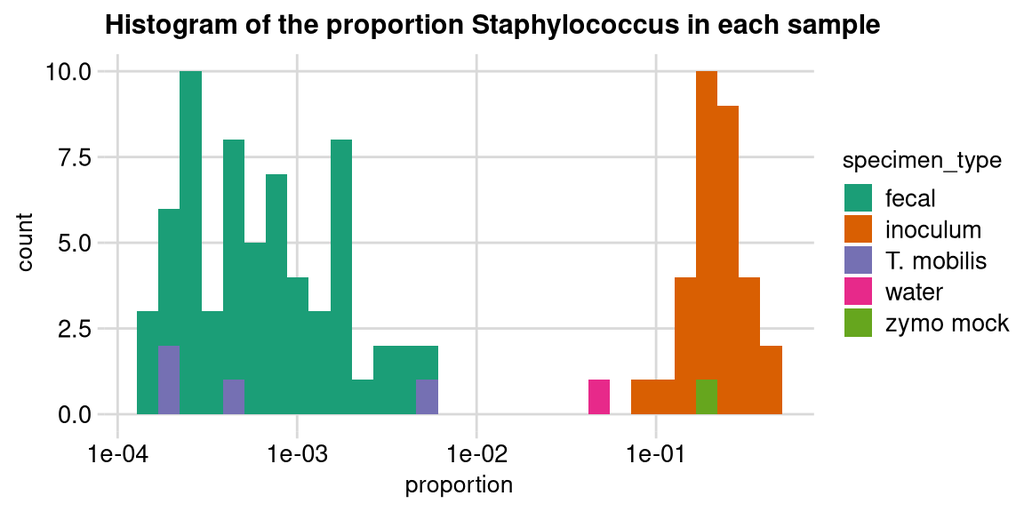

```r
ps0 %>%
  transform_sample_counts(close_elts) %>%
  # prune_taxa("ASV6", .) %>%
  subset_taxa(genus == "Staphylococcus") %>%
  as_tibble %>%
  mutate_at("specimen_type", as.character) %>%
  mutate(specimen_type = case_when(
      str_detect(sample, "zymo") ~ "zymo mock",
      str_detect(sample, "water") ~ "water",
      TRUE ~ specimen_type
    )
  ) %>%
  rename(proportion = abundance) %>%
  ggplot(aes(proportion, fill = specimen_type)) +
  geom_histogram() +
  scale_fill_brewer(type = "qual", palette = 2) +
  scale_x_log10() +
  labs(title = "Histogram of the proportion Staphylococcus in each sample") +
  theme(title = element_text(size = 10))
```

```r
ggsave(
  here("results/figures", "2020-02-17-staph-contam.pdf"),
  width = 6,
  height = 3
)
```

```r
ps %>% subset_taxa(genus == "Staphylococcus") %>% refseq %>% as.character
```

```
##                                                                                                                                                                                                                                                         A1_ASV6
## "TACGTAGGTGGCAAGCGTTATCCGGAATTATTGGGCGTAAAGCGCGCGTAGGCGGTTTTT…"
```

```r
ps %>% subset_taxa(genus == "Staphylococcus") %>% tax_table
```

```
## Taxonomy Table:     [1 taxa by 7 taxonomic ranks]:
##         kingdom    phylum       class     order
## A1_ASV6 "Bacteria" "Firmicutes" "Bacilli" "Staphylococcales"
##         family              genus
## A1_ASV6 "Staphylococcaceae" "Staphylococcus"
##         species
## A1_ASV6 "argenteus/aureus/capitis/caprae/devriesei/epidermidis/equorum/haemolyticus/hominis/lugdunensis/pasteuri/petrasii/phage/saccharolyticus/saprophyticus/schweitzeri/simiae/warneri"
```

## Inspect Bacillus contamination

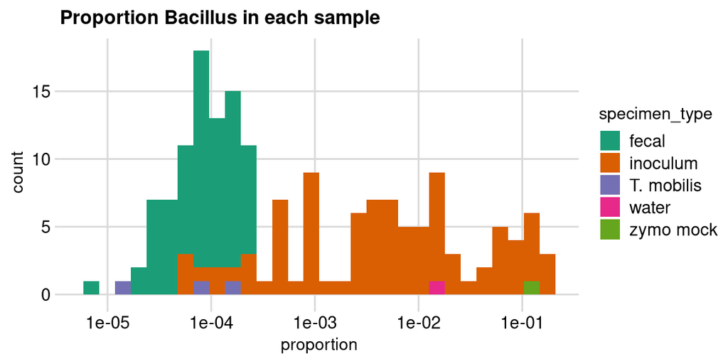

```r
ps0 %>%
  transform_sample_counts(close_elts) %>%
  subset_taxa(genus == "Bacillus") %>%
  as_tibble %>%
  mutate_at("specimen_type", as.character) %>%
  mutate(specimen_type = case_when(
      str_detect(sample, "zymo") ~ "zymo mock",
      str_detect(sample, "water") ~ "water",
      TRUE ~ specimen_type
    )
  ) %>%
  rename(proportion = abundance) %>%
  ggplot(aes(proportion, fill = specimen_type)) +
  geom_histogram() +
  scale_fill_brewer(type = "qual", palette = 2) +
  scale_x_log10() +
  labs(title = "Proportion Bacillus in each sample") +
  theme(title = element_text(size = 10))
```

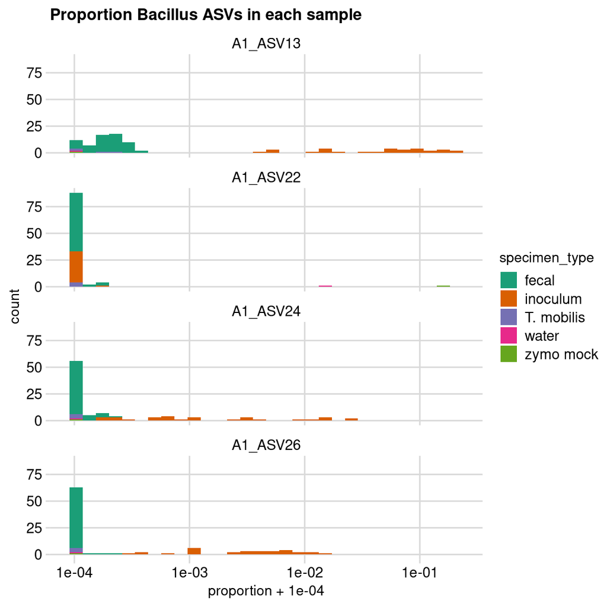

```r
ps0 %>%
  transform_sample_counts(close_elts) %>%
  # prune_taxa(c("ASV13", "ASV24", "ASV26"), .) %>%
  subset_taxa(genus == "Bacillus") %>%
  as_tibble %>%
  mutate_at("specimen_type", as.character) %>%
  mutate(specimen_type = case_when(
      str_detect(sample, "zymo") ~ "zymo mock",
      str_detect(sample, "water") ~ "water",
      TRUE ~ specimen_type
    )
  ) %>%
  rename(proportion = abundance) %>%
  ggplot(aes(proportion + 1e-4, fill = specimen_type)) +
  geom_histogram() +
  scale_fill_brewer(type = "qual", palette = 2) +
  scale_x_log10() +
  facet_wrap(~taxon, ncol = 1) +
  labs(title = "Proportion Bacillus ASVs in each sample") +
  theme(title = element_text(size = 10))
```

```r
ggsave(
  here("results/figures", "2020-02-25-bacillus-contam.pdf"),
  width = 6,
  height = 8
)
```

Sequences of the contams:

```r
ps0 %>%
  subset_taxa(genus == "Staphylococcus") %>%
  refseq %>%
  as.character
```

```
##                                                                                                                                                                                                                                                         A1_ASV6
## "TACGTAGGTGGCAAGCGTTATCCGGAATTATTGGGCGTAAAGCGCGCGTAGGCGGTTTTT…"
```

```r
ps0 %>%
  subset_taxa(genus == "Bacillus") %>%
  refseq %>%
  as.character
```

```
##                                                                                                                                                                                                                                                        A1_ASV13
## "TACGTAGGTGGCAAGCGTTATCCGGAATTATTGGGCGTAAAGCGCGCGCAGGTGGTTTCT…"
##                                                                                                                                                                                                                                                        A1_ASV22
## "TACGTAGGTGGCAAGCGTTGTCCGGAATTATTGGGCGTAAAGGGCTCGCAGGCGGTTCCT…"
##                                                                                                                                                                                                                                                        A1_ASV24
## "TACGTAGGTGGCAAGCGTTGTCCGGAATTATTGGGCGTAAAGGGCTCGCAGGCGGTTTCT…"
##                                                                                                                                                                                                                                                        A1_ASV26
## "TACGTAGGTGGCAAGCGTTATCCGGAATTATTGGGCGTAAAGCGCGCGCAGGTGGTTTCT…"
```

### Check DNA concentration patterns

```r
tb <- ps1 %>%
  subset_samples(specimen_type == "inoculum") %>%
  transform_sample_counts(close_elts) %>%
  prune_taxa(c("A1_ASV6", "A1_ASV13", "A1_ASV24"), .) %>%
  as_tibble
```

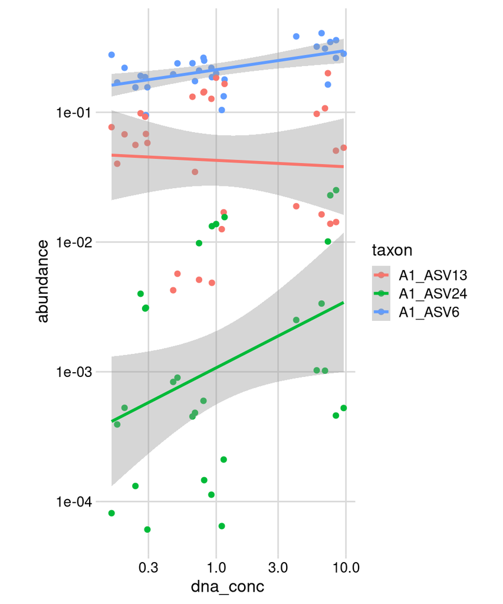

```r
tb %>%
  ggplot(aes(dna_conc, abundance, color = taxon)) +
  geom_point() +
  scale_x_log10() +
  scale_y_log10() +
  geom_smooth(method = "lm") +
  coord_fixed()
```

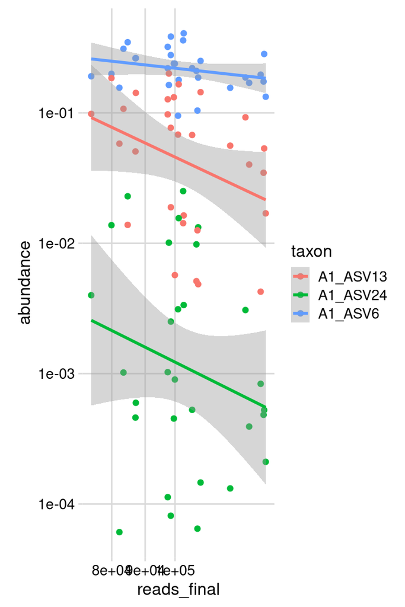

```r
tb %>%
  ggplot(aes(reads_final, abundance, color = taxon)) +
  geom_point() +
  scale_x_log10() +
  scale_y_log10() +
  geom_smooth(method = "lm") +
  coord_fixed(ratio = 0.2)
```